# RT assay

- Show All Code
- Hide All Code
- View Source

Simulate the RT assay of Q’s group with our model

Authors

Nicholas Harbour

Markus Owen

Published

August 12, 2024, 11:03:05

Modified

August 12, 2024, 11:02:43

# 1 Import packages

```python
import numpy as np
import matplotlib.pyplot as plt
import pandas as pd
import scipy.stats as stats
from scipy.stats import lognorm
import matplotlib.colors as mcolors
```

# 2 import functions

all functions are in: “notebooks/gsc_model_functions.py”

```python
import gsc_model_functions as gmf
```

For this we need to load in the patient data and calculate the distribution parameters

```python
# load in the patient survival data
historic_df = pd.read_csv("Data/Rho_D_data.csv")
censored_str = "Censorship (1=censored)"
survival_str = "Overall Survival"
# only keep patients that weren't censored
historic_df = historic_df[historic_df[censored_str] == 0]
# cut off patients that had very high proliferation rate
historic_df = historic_df[historic_df["PIHNA rho"] < 100 ]
historic_df[censored_str] = True

# fit distribution to the data
dist_name = 'lognorm'  # Replace with the desired distribution name
dist = getattr(stats, dist_name)
params = dist.fit(historic_df["PIHNA rho"])

shape = params[0]
loc = params[1]
scale = params[-1]
```

# 3 Simulations of radiotherapy assays.

## 3.1 Changing the concetration of BMP4

Data is for representative patient derived BTIC pre-exposed to different delivery combinations of 100 ng/ml BMP4 for 48 hours followed by different doses of radiation.

```python
### import params
from gsc_model_params import *

s0 = 0.1 # Initial GSCs
dt = 0.05 # time step
t_rad = 2 # time of radiotherapy
t_assay = dt # time of assay after radiotherapy
t_final = t_rad + t_assay

RT_doses = [0,2,4,6,8,10] # diffent doses of radiation used in assay
BMP4_doses = [0,0.5,10] # different doses of BMP4 used in assay
BMP4_colors = list(mcolors.TABLEAU_COLORS)

nRT = len(RT_doses) # number of RT doses
nB = len(BMP4_doses) # number of BMP4 doses

# to store time and tumor size at RT and survival assay
RT_pre_size = np.zeros((nRT,nB))
RT_pre_t = np.zeros((nRT,nB))
RT_post_size = np.zeros((nRT,nB))
RT_post_t = np.zeros((nRT,nB))
assay_size = np.zeros((nRT,nB))
assay_t = np.zeros((nRT,nB))

# use the mean of the fitted distribution as an example realistic proliferation rate
pro_rate = loc+scale*np.exp(shape**2/2)

# Define proliferation rates for the different cell pops
mv = mv_rho_scale*pro_rate*np.ones(n)
ms = ms_mv_scale*mv[0]
mv[n-1] = 0

# calc alpha as proportional to rho
alpha = gmf.calc_alpha_from_rho(mv[0],10*alpha_rho_scale)
beta = gmf.calc_beta(alpha)


# set up time grid
t = np.arange(0, t_final+dt/2, dt)
nt = len(t)


# set up array to store model solution
u_all = []
VS_all = []
N_all = []


for iB in range(nB) :
    for j in range(nRT):

        # set up array to store model solution
        u = np.zeros((nt,n+1))
        VS = np.zeros(nt)
        N = np.zeros(nt)

        # define IC
        u[0,0] = s0
        VS[0] = np.sum(u[0,1:n+1]) # sum the 1th to nth entries
        N[0] = u[0,0] + VS[0]

        i = 0
        while t[i] < t_final:
                if t[i] <= t_rad :
                    Ps = Ps_min + (Ps_max - Ps_min)*(1 / (1 + psi*BMP4_doses[iB]))
                else :
                    Ps = Ps_max

                u[i+1,:] = u[i,:] + dt * gmf.gsc_model_dudt(u[i,:],n,Ps,k,ms,mv,delta_s,delta_v)
                # apply radiation
                if t[i] == t_rad :
                    u[i+1,:] = gmf.radiation(u[i+1,:],alpha,beta,eta,mu,d=RT_doses[j])
                    RT_pre_size[j,iB] = np.sum(u[i,:])
                    RT_pre_t[j,iB] = t[i]
                    RT_post_size[j,iB] = np.sum(u[i+1,:])
                    RT_post_t[j,iB] = t[i+1]

                VS[i+1] = np.sum(u[i+1,1:n+1])
                N[i+1] = u[i+1,0] + VS[i+1]

                i = i + 1

        u_all.append(u)
        VS_all.append(VS)
        N_all.append(N)
```

plot size of growth and percentage of GSCs in assay

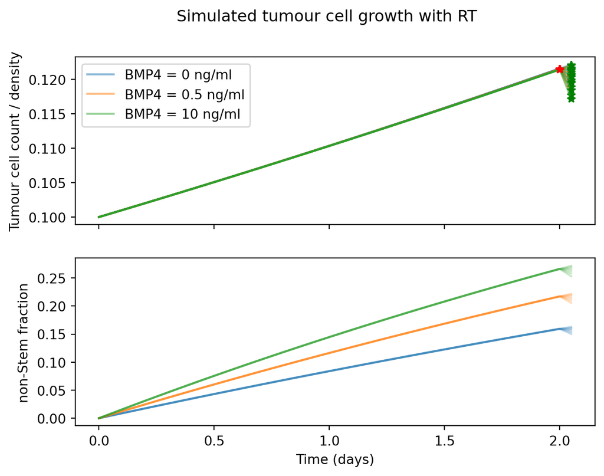

```python
fig, axs = plt.subplots(2, sharex=True)
w = 0
BMP4_colors = list(mcolors.TABLEAU_COLORS)
for iB in range(nB) :
    for j in range(nRT):

        axs[1].plot(t,VS_all[w]/N_all[w], BMP4_colors[iB], alpha=0.25)
        axs[0].plot(t,N_all[w],BMP4_colors[iB], alpha = 0.5)

        axs[0].plot(RT_pre_t[j,iB],RT_pre_size[j,iB],'r*',label='_nolegend_')
        axs[0].plot(RT_post_t[j,iB],RT_post_size[j,iB],'g*',label='_nolegend_')

        w = w + 1

axs[1].set(xlabel="Time (days)")
axs[1].set(ylabel="non-Stem fraction")
axs[0].set(ylabel="Tumour cell count / density")
axs[1].set(ylabel="non-Stem fraction")
fig.suptitle("Simulated tumour cell growth with RT")
leg = axs[0].legend(["BMP4 = 0 ng/ml","BMP4 = 0.5 ng/ml","BMP4 = 10 ng/ml"])
leg.legend_handles[0].set_color('tab:blue')
leg.legend_handles[1].set_color('tab:orange')
leg.legend_handles[2].set_color('tab:green')
```

Plot simulated dose respones

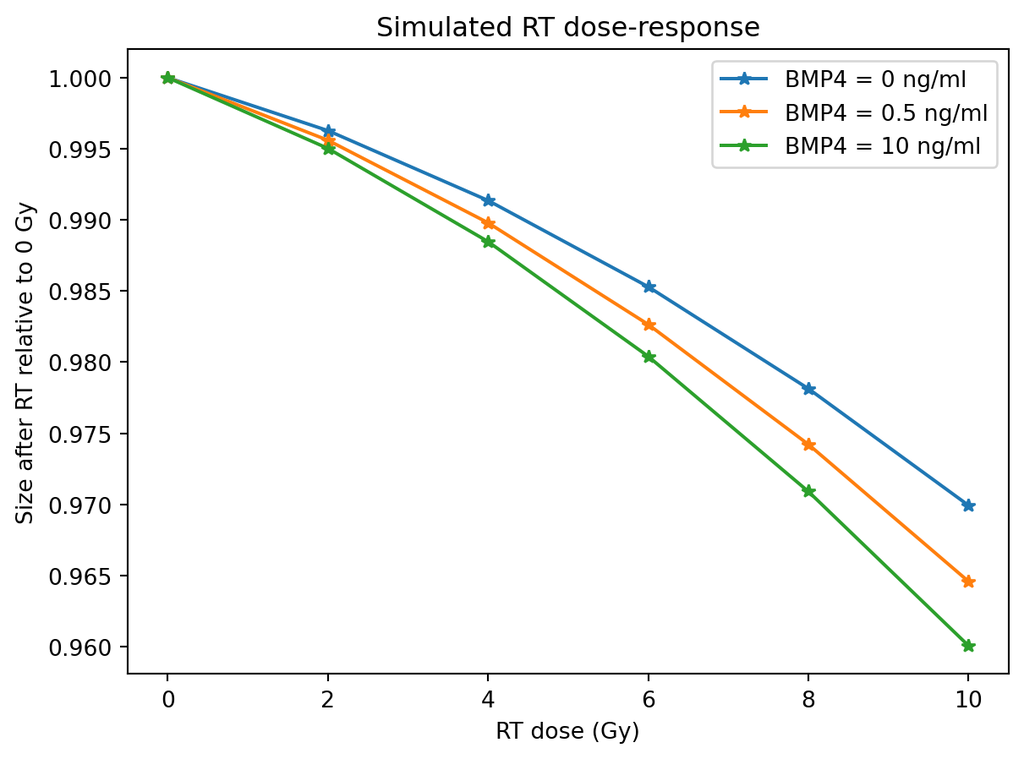

```python
fig_DR2, ax_DR2 = plt.subplots()
ax_DR2.plot(RT_doses,RT_post_size/RT_post_size[0,:],'-*')
ax_DR2.set(xlabel="RT dose (Gy)")
ax_DR2.set(ylabel="Size after RT relative to 0 Gy")
ax_DR2.set_title("Simulated RT dose-response")
ax_DR2.legend(["BMP4 = 0 ng/ml","BMP4 = 0.5 ng/ml","BMP4 = 10 ng/ml"])
```

## 3.2 Changing the sensitivity (psi) of the GSCs to BMP4

We can simulate the same thing but consider varying the patient specific sensitivity $\psi$ to rather than BMP4 dose.

```python
### import params
from gsc_model_params import *

### override some parameters ###
s0 = 0.1 # Initial GSCs
dt = 0.05 # time step
t_rad = 2 # time of radiotherapy
t_assay = dt # time of assay after radiotherapy
t_final = t_rad + t_assay

RT_doses = [0,2,4,6,8,10] # diffent doses of radiation used in assay
psi_values = [0,0.1,50] # different values of psi used in assay
psi_colors = list(mcolors.TABLEAU_COLORS)

BMP4_dose = 10 # bmp4 dose is now fixed

nRT = len(RT_doses) # number of RT doses
npsi = len(psi_values) # number of BMP4 doses

# to store time and tumor size at RT and survival assay
RT_pre_size = np.zeros((nRT,npsi))
RT_pre_t = np.zeros((nRT,npsi))
RT_post_size = np.zeros((nRT,npsi))
RT_post_t = np.zeros((nRT,npsi))
assay_size = np.zeros((nRT,npsi))
assay_t = np.zeros((nRT,npsi))

# use the mean of the fitted distribution as an example realistic proliferation rate
pro_rate = loc+scale*np.exp(shape**2/2)


# Define proliferation rates for the diffent cell pops
mv = mv_rho_scale*pro_rate*np.ones(n)
ms = ms_mv_scale*mv[0]
mv[n-1] = 0

# calc alpha as proportional to rho
alpha = gmf.calc_alpha_from_rho(mv[0],10*alpha_rho_scale)
beta = gmf.calc_beta(alpha)

# set up time grid
t = np.arange(0, t_final+dt/2, dt)
nt = len(t)


# set up array to store model solution
u_all = []
VS_all = []
N_all = []


for ipsi in range(npsi) :
    for j in range(nRT):

        # set up array to store model solution
        u = np.zeros((nt,n+1))
        VS = np.zeros(nt)
        N = np.zeros(nt)

        # define IC
        u[0,0] = s0
        VS[0] = np.sum(u[0,1:n+1]) # sum the 1th to nth entries
        N[0] = u[0,0] + VS[0]

        i = 0
        while t[i] < t_final:
                if t[i] <= t_rad :
                    Ps = Ps_min + (Ps_max - Ps_min)*(1 / (1 + psi_values[ipsi]*BMP4_dose))
                else :
                    Ps = Ps_max

                u[i+1,:] = u[i,:] + dt * gmf.gsc_model_dudt(u[i,:],n,Ps,k,ms,mv,delta_s,delta_v)
                # apply radiation
                if t[i] == t_rad :
                    u[i+1,:] = gmf.radiation(u[i+1,:],alpha,beta,eta,mu,d=RT_doses[j])
                    RT_pre_size[j,ipsi] = np.sum(u[i,:])
                    RT_pre_t[j,ipsi] = t[i]
                    RT_post_size[j,ipsi] = np.sum(u[i+1,:])
                    RT_post_t[j,ipsi] = t[i+1]

                VS[i+1] = np.sum(u[i+1,1:n+1])
                N[i+1] = u[i+1,0] + VS[i+1]

                i = i + 1

        u_all.append(u)
        VS_all.append(VS)
        N_all.append(N)
```

Make the same plots as for BMP4 dose but for psi

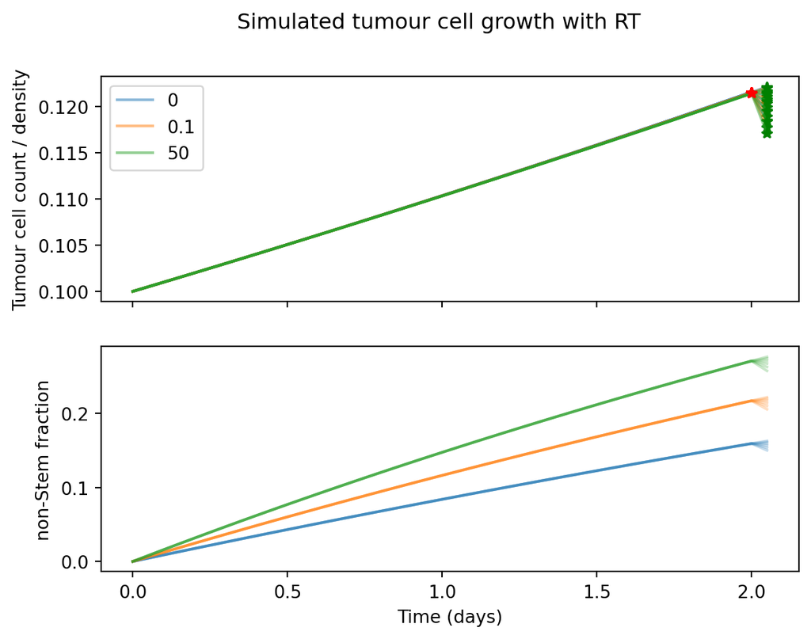

```python
fig, axs = plt.subplots(2, sharex=True)
w = 0
BMP4_colors = list(mcolors.TABLEAU_COLORS)
for ipsi in range(npsi) :
    for j in range(nRT):

        axs[1].plot(t,VS_all[w]/N_all[w], psi_colors[ipsi], alpha=0.25)
        axs[0].plot(t,N_all[w],psi_colors[ipsi], alpha = 0.5)

        axs[0].plot(RT_pre_t[j,ipsi],RT_pre_size[j,ipsi],'r*',label='_nolegend_')
        axs[0].plot(RT_post_t[j,ipsi],RT_post_size[j,ipsi],'g*',label='_nolegend_')

        w = w + 1

axs[1].set(xlabel="Time (days)")
axs[1].set(ylabel="non-Stem fraction")
axs[0].set(ylabel="Tumour cell count / density")
axs[1].set(ylabel="non-Stem fraction")
fig.suptitle("Simulated tumour cell growth with RT")
leg = axs[0].legend(psi_values)
leg.legend_handles[0].set_color('tab:blue')
leg.legend_handles[1].set_color('tab:orange')
leg.legend_handles[2].set_color('tab:green')
```

Plot simulated dose respones

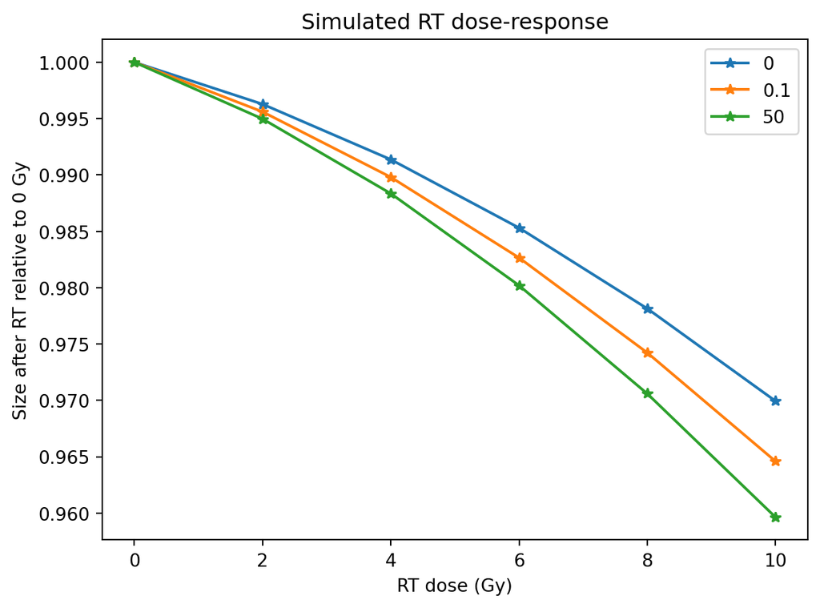

```python
fig_DR2, ax_DR2 = plt.subplots()
ax_DR2.plot(RT_doses,RT_post_size/RT_post_size[0,:],'-*')
ax_DR2.set(xlabel="RT dose (Gy)")
ax_DR2.set(ylabel="Size after RT relative to 0 Gy")
ax_DR2.set_title("Simulated RT dose-response")
ax_DR2.legend(psi_values)
```

With our in vivo number we do not get much effect of BMP4. But this is because to get 2% GSCs we are assuming an in vivo environemnt in which there are natural differentiation promoters such as BMP4. IN vitro experiments there would be no endogenous BMP4 / differentiation promoters so the value of Ps would be much higher closer to 1.

## 3.3 Assuming no differentation promoter in vitro

```python
### import params
from gsc_model_params import *

### override some parameters ###
Ps_max = 1 # Max probability of self renewal - CHANGED FROM 0.56

s0 = 0.1 # Initial GSCs
dt = 0.05 # time step
t_rad = 2 # time of radiotherapy
t_assay = dt # time of assay after radiotherapy
t_final = t_rad + t_assay

RT_doses = [0,2,4,6,8,10] # diffent doses of radiation used in assay
psi_values = [0,0.1,50] # different values of psi used in assay
psi_colors = list(mcolors.TABLEAU_COLORS)

BMP4_dose = 10 # bmp4 dose is now fixed

nRT = len(RT_doses) # number of RT doses
npsi = len(psi_values) # number of BMP4 doses

# to store time and tumor size at RT and survival assay
RT_pre_size = np.zeros((nRT,npsi))
RT_pre_t = np.zeros((nRT,npsi))
RT_post_size = np.zeros((nRT,npsi))
RT_post_t = np.zeros((nRT,npsi))
assay_size = np.zeros((nRT,npsi))
assay_t = np.zeros((nRT,npsi))

# use the mean of the fitted distribution as an example realistic proliferation rate
pro_rate = loc+scale*np.exp(shape**2/2)


# Define proliferation rates for the diffent cell pops
mv = mv_rho_scale*pro_rate*np.ones(n)
ms = ms_mv_scale*mv[0]
mv[n-1] = 0

# calc alpha as proportional to rho
alpha = gmf.calc_alpha_from_rho(mv[0],10*alpha_rho_scale)
beta = gmf.calc_beta(alpha)

# set up time grid
t = np.arange(0, t_final+dt/2, dt)
nt = len(t)


# set up array to store model solution
u_all = []
VS_all = []
N_all = []


for ipsi in range(npsi) :
    for j in range(nRT):

        # set up array to store model solution
        u = np.zeros((nt,n+1))
        VS = np.zeros(nt)
        N = np.zeros(nt)

        # define IC
        u[0,0] = s0
        VS[0] = np.sum(u[0,1:n+1]) # sum the 1th to nth entries
        N[0] = u[0,0] + VS[0]

        i = 0
        while t[i] < t_final:
                if t[i] <= t_rad :
                    Ps = Ps_min + (Ps_max - Ps_min)*(1 / (1 + psi_values[ipsi]*BMP4_dose))
                else :
                    Ps = Ps_max

                u[i+1,:] = u[i,:] + dt * gmf.gsc_model_dudt(u[i,:],n,Ps,k,ms,mv,delta_s,delta_v)
                # apply radiation
                if t[i] == t_rad :
                    u[i+1,:] = gmf.radiation(u[i+1,:],alpha,beta,eta,mu,d=RT_doses[j])
                    RT_pre_size[j,ipsi] = np.sum(u[i,:])
                    RT_pre_t[j,ipsi] = t[i]
                    RT_post_size[j,ipsi] = np.sum(u[i+1,:])
                    RT_post_t[j,ipsi] = t[i+1]

                VS[i+1] = np.sum(u[i+1,1:n+1])
                N[i+1] = u[i+1,0] + VS[i+1]

                i = i + 1

        u_all.append(u)
        VS_all.append(VS)
        N_all.append(N)
```

Make the same plots as for BMP4 dose but for psi

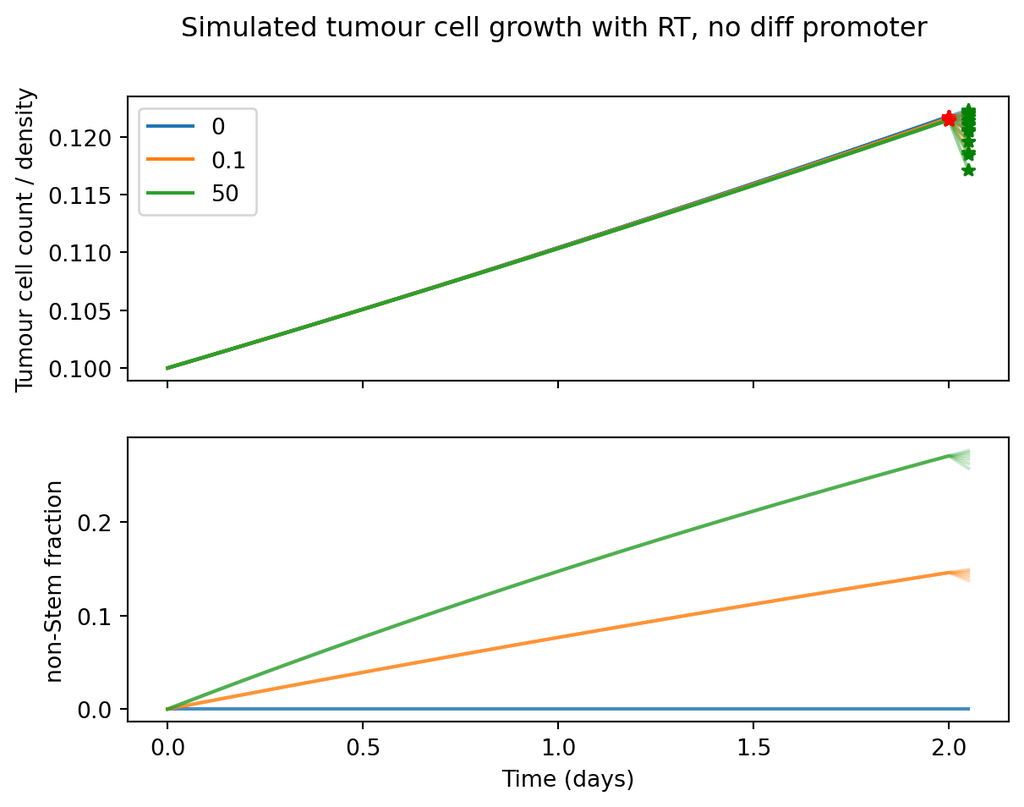

```python
fig, axs = plt.subplots(2, sharex=True)
w = 0
BMP4_colors = list(mcolors.TABLEAU_COLORS)
for ipsi in range(npsi) :
    for j in range(nRT):

        axs[1].plot(t,VS_all[w]/N_all[w], psi_colors[ipsi], alpha=0.25)
        axs[0].plot(t,N_all[w],psi_colors[ipsi], alpha = 0.5)

        axs[0].plot(RT_pre_t[j,ipsi],RT_pre_size[j,ipsi],'r*',label='_nolegend_')
        axs[0].plot(RT_post_t[j,ipsi],RT_post_size[j,ipsi],'g*',label='_nolegend_')

        w = w + 1

axs[1].set(xlabel="Time (days)")
axs[1].set(ylabel="non-Stem fraction")
axs[0].set(ylabel="Tumour cell count / density")
axs[1].set(ylabel="non-Stem fraction")
fig.suptitle("Simulated tumour cell growth with RT, no diff promoter")
leg = axs[0].legend(psi_values)
leg.legend_handles[0].set_color('tab:blue')
leg.legend_handles[1].set_color('tab:orange')
leg.legend_handles[2].set_color('tab:green')
leg.legend_handles[0].set_alpha(1)
leg.legend_handles[1].set_alpha(1)
leg.legend_handles[2].set_alpha(1)
```

Plot simulated dose respones

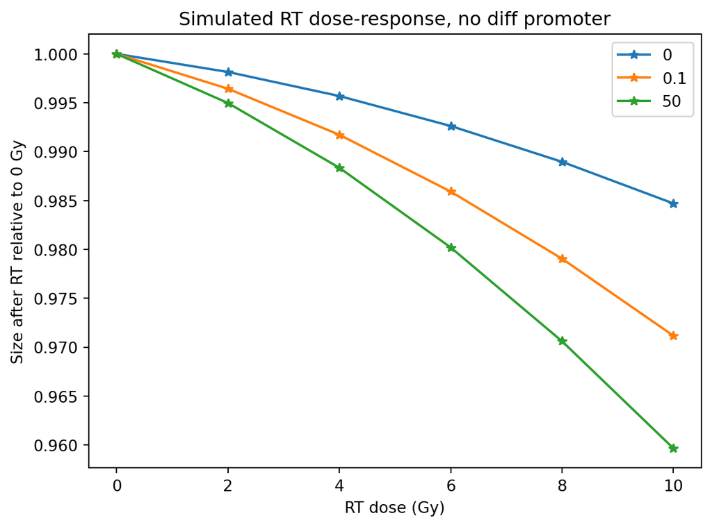

```python
fig_DR2, ax_DR2 = plt.subplots()
ax_DR2.plot(RT_doses,RT_post_size/RT_post_size[0,:],'-*')
ax_DR2.set(xlabel="RT dose (Gy)")
ax_DR2.set(ylabel="Size after RT relative to 0 Gy")
ax_DR2.set_title("Simulated RT dose-response, no diff promoter")
ax_DR2.legend(psi_values)
```

# 4 Replicate experimental results

We have experimentall doubling times for some of the cell lines:

- **GBM1a** - has a doubling time of 54.71329hrs (2.2797204166666667 days), this gives a growth rate in terms rho 1/year as $m_s$ = 65 (roughly)
- **QNS120** - has a doubling time of 43.5243

## 4.1 GBM1a

doubling time is 54,71329hrs (2.27days) according to this the growth should be

$$N(t) = N_0 2^{t/T}$$

```python
N = s0*2**(48/54.71329)
print("Expected size of colon after 48hrs for GMB1a")
print(N)
```

```
Expected size of colon after 48hrs for GMB1a
0.18369349786739397
```

```python
### import params
from gsc_model_params import *

### override some parameters ###
Ps_max = 1 # Max probability of self renewal
Ps_min = 0

s0 = 0.1 # Initial GSCs
dt = 0.01 # time step
t_rad = 2 # time of radiotherapy
t_assay = dt # time of assay after radiotherapy
t_final = t_rad + t_assay

RT_doses = [0,2,4,6] # diffent doses of radiation used in assay
psi_values = [0,0.115] # different values of psi used in assay
psi_colors = list(mcolors.TABLEAU_COLORS)

BMP4_dose = 10 # bmp4 dose is now fixed

nRT = len(RT_doses) # number of RT doses
npsi = len(psi_values) # number of BMP4 doses

# to store time and tumor size at RT and survival assay
RT_pre_size = np.zeros((nRT,npsi))
RT_pre_t = np.zeros((nRT,npsi))
RT_post_size = np.zeros((nRT,npsi))
RT_post_t = np.zeros((nRT,npsi))
assay_size = np.zeros((nRT,npsi))
assay_t = np.zeros((nRT,npsi))

# use the mean of the fitted distribution as an example realistic proliferation rate
pro_rate = 65


# Define proliferation rates for the diffent cell pops
mv = mv_rho_scale*pro_rate*np.ones(n)
ms = ms_mv_scale*mv[0]
mv[n-1] = 0

# calc alpha as proportional to rho
#alpha = gmf.calc_alpha_from_rho(pro_rate, alpha_rho_scale)
#beta = gmf.calc_beta(alpha, ratio=3)

# According to the RT data fits for GBM1a we get
alpha = 0.22*6
beta = 0.08*6


# set up time grid
t = np.arange(0, t_final+dt/2, dt)
nt = len(t)


# set up array to store model solution
u_all = []
VS_all = []
N_all = []


for ipsi in range(npsi) :
    for j in range(nRT):

        # set up array to store model solution
        u = np.zeros((nt,n+1))
        VS = np.zeros(nt)
        N = np.zeros(nt)

        # define IC
        u[0,0] = s0
        VS[0] = np.sum(u[0,1:n+1]) # sum the 1th to nth entries
        N[0] = u[0,0] + VS[0]

        i = 0
        while t[i] < t_final:
                if t[i] <= t_rad :
                    Ps = Ps_min + (Ps_max - Ps_min)*(1 / (1 + psi_values[ipsi]*BMP4_dose))
                else :
                    Ps = Ps_max

                u[i+1,:] = u[i,:] + dt * gmf.gsc_model_dudt(u[i,:],n,Ps,k,ms,mv,delta_s,delta_v)
                # apply radiation
                if t[i] == t_rad :
                    u[i+1,:] = gmf.radiation(u[i+1,:],alpha,beta,eta,mu,d=RT_doses[j])
                    RT_pre_size[j,ipsi] = np.sum(u[i,:])
                    RT_pre_t[j,ipsi] = t[i]
                    RT_post_size[j,ipsi] = np.sum(u[i+1,:])
                    RT_post_t[j,ipsi] = t[i+1]

                VS[i+1] = np.sum(u[i+1,1:n+1])
                N[i+1] = u[i+1,0] + VS[i+1]

                i = i + 1

        u_all.append(u)
        VS_all.append(VS)
        N_all.append(N)
        print("Actuall size after 48hrs")
        print(N[-2]) # need to print second last item as the last one has had RT applied

print("Stem cell fraction just before RT")
print(1- VS[-2]/N[-2])
print("According to DLQ stem cell fraction should be")
print(0.5210781)
```

```
Actuall size after 48hrs
0.18420280541577466
Actuall size after 48hrs
0.18420280541577466
Actuall size after 48hrs
0.18420280541577466
Actuall size after 48hrs
0.18420280541577466
Actuall size after 48hrs
0.18335231461050427
Actuall size after 48hrs
0.18335231461050427
Actuall size after 48hrs
0.18335231461050427
Actuall size after 48hrs
0.18335231461050427
Stem cell fraction just before RT
0.5214819214850532
According to DLQ stem cell fraction should be
0.5210781
```

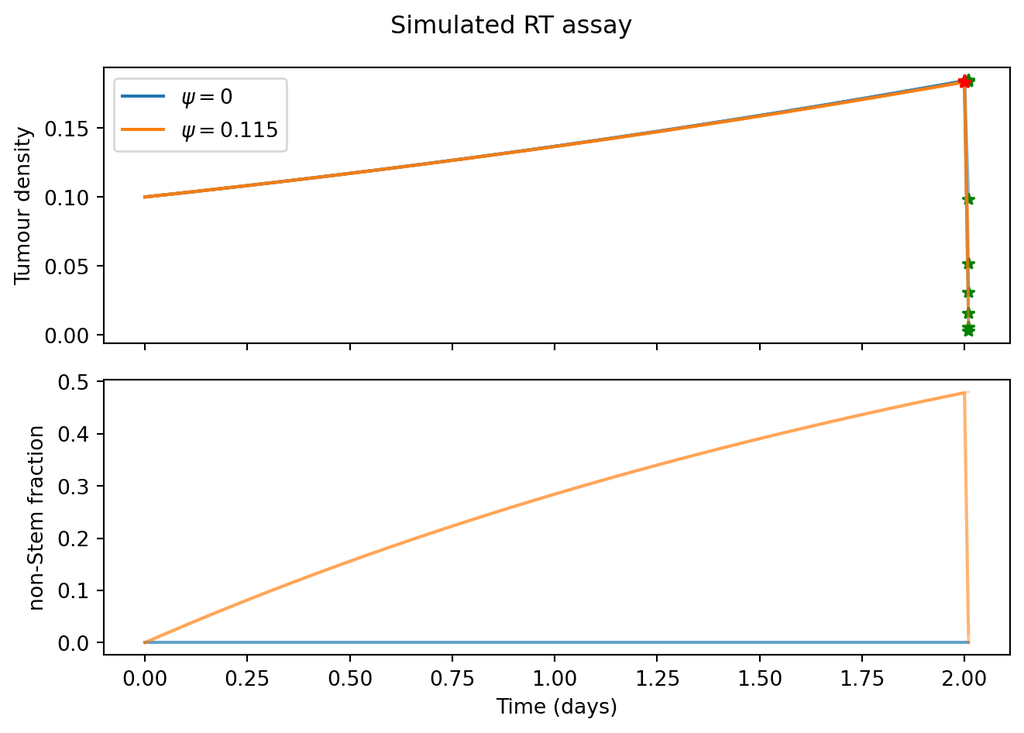

```python
fig, axs = plt.subplots(2, sharex=True)
w = 0
BMP4_colors = list(mcolors.TABLEAU_COLORS)
for ipsi in range(npsi) :
    for j in range(nRT):

        axs[1].plot(t,VS_all[w]/N_all[w], psi_colors[ipsi], alpha=0.25)
        axs[0].plot(t,N_all[w],psi_colors[ipsi], alpha = 0.5)

        axs[0].plot(RT_pre_t[j,ipsi],RT_pre_size[j,ipsi],'r*',label='_nolegend_')
        axs[0].plot(RT_post_t[j,ipsi],RT_post_size[j,ipsi],'g*',label='_nolegend_')

        w = w + 1

axs[1].set(xlabel="Time (days)")
axs[1].set(ylabel="non-Stem fraction")
axs[0].set(ylabel="Tumour density")
axs[1].set(ylabel="non-Stem fraction")
fig.suptitle("Simulated RT assay")
leg = axs[0].legend([r"$\psi = 0$",fr"$\psi = {psi_values[1]}$"], loc='upper left')
leg.legend_handles[0].set_color('tab:blue')
leg.legend_handles[1].set_color('tab:orange')
#leg.legend_handles[2].set_color('tab:green')
#leg.legend_handles[3].set_color('tab:red')
#leg.legend_handles[4].set_color('tab:purple')
leg.legend_handles[0].set_alpha(1)
leg.legend_handles[1].set_alpha(1)
#leg.legend_handles[2].set_alpha(1)
#leg.legend_handles[3].set_alpha(1)
#leg.legend_handles[4].set_alpha(1)
plt.tight_layout()
plt.savefig("png/simulated_RT_assay_GBM1a.png")
plt.savefig("svg/simulated_RT_assay_GBM1a.svg")
plt.show()
```

Plot simulated dose respones

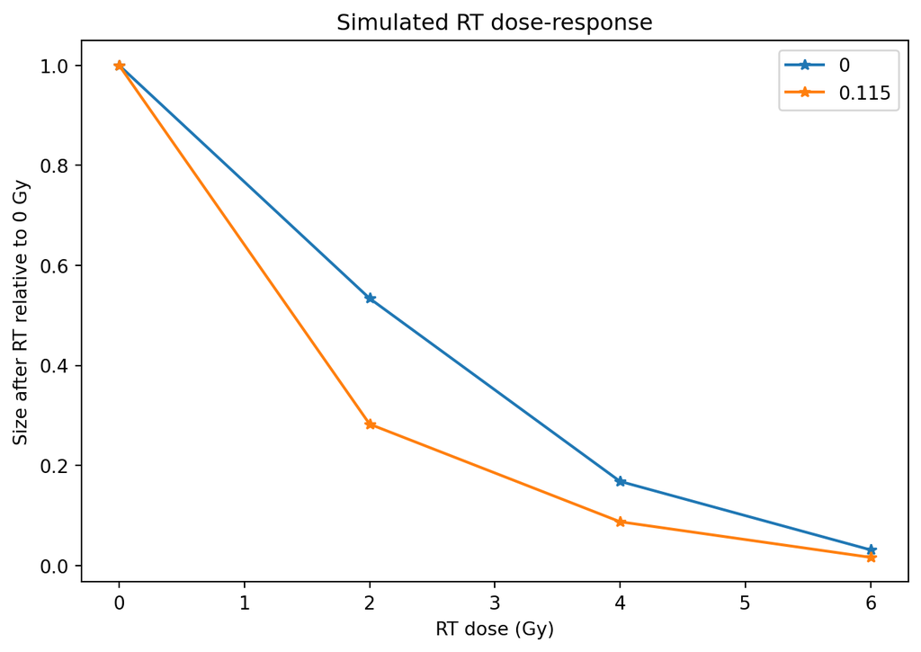

```python
fig_DR2, ax_DR2 = plt.subplots()
ax_DR2.plot(RT_doses,RT_post_size/RT_post_size[0,:],'-*')
ax_DR2.set(xlabel="RT dose (Gy)")
ax_DR2.set(ylabel="Size after RT relative to 0 Gy")
ax_DR2.set_title("Simulated RT dose-response")
ax_DR2.legend(psi_values)
plt.tight_layout()
plt.show()
```

Load in the real survival data to fit to.

```
['r01']
['r01', 'r02']
['r01', 'r02', 'r03']
['r01', 'r02', 'r03']
['r01', 'r02', 'r03']
['r01', 'r02', 'r03']
['r01', 'r02', 'r03', 'r04']
['r01', 'r02', 'r03', 'r04', 'r05']
      cline     p  att  rep group  Exp  dose  ncells  scene  ncolonies  \
0     GBM1a  14.0    1  r01  CTRL  r01     0     200      1         41
1     GBM1a  14.0    1  r01  CTRL  r02     0     200     16         49
2     GBM1a  14.0    1  r01  CTRL  r03     0     200     17         41
3     GBM1a  14.0    1  r01  CTRL  r04     0     200     32         43
4     GBM1a  14.0    1  r01  CTRL  r05     0     200     33         47
...     ...   ...  ...  ...   ...  ...   ...     ...    ...        ...
2526  GBM1a  23.0    5  r05  S100  r06     6    2000     26         14
2527  GBM1a  23.0    5  r05  E100  r06     6    2000     27         13
2528  GBM1a  23.0    5  r05  B100  r06     6    2000     28          2
2529  GBM1a  23.0    5  r05   FBS  r06     6    2000     29         21
2530  GBM1a  23.0    5  r05  CTRL  r06     6    2000     30         23

          pe         token  group_id   norm_pe
0     0.2050  GBM1a_CTRL_0         1  0.884892
1     0.2450  GBM1a_CTRL_0         1  1.057554
2     0.2050  GBM1a_CTRL_0         1  0.884892
3     0.2150  GBM1a_CTRL_0         1  0.928058
4     0.2350  GBM1a_CTRL_0         1  1.014388
...      ...           ...       ...       ...
2526  0.0070  GBM1a_S100_6         8  0.035959
2527  0.0065  GBM1a_E100_6         4  0.023325
2528  0.0010  GBM1a_B100_6         6  0.012605
2529  0.0105   GBM1a_FBS_6         2  0.036124
2530  0.0115  GBM1a_CTRL_6         1  0.040780

[864 rows x 14 columns]
      cline     p  att  rep group  Exp  dose  ncells  scene  ncolonies  \
180   GBM1a  14.0    1  r01  B100  r01     0     200      6         61
181   GBM1a  14.0    1  r01  B100  r02     0     200     11         59
182   GBM1a  14.0    1  r01  B100  r03     0     200     22         62
183   GBM1a  14.0    1  r01  B100  r04     0     200     27         71
184   GBM1a  14.0    1  r01  B100  r05     0     200     38         73
...     ...   ...  ...  ...   ...  ...   ...     ...    ...        ...
2508  GBM1a  23.0    5  r05  B100  r02     6    2000      8          3
2513  GBM1a  23.0    5  r05  B100  r03     6    2000     13          1
2518  GBM1a  23.0    5  r05  B100  r04     6    2000     18          5
2523  GBM1a  23.0    5  r05  B100  r05     6    2000     23          4
2528  GBM1a  23.0    5  r05  B100  r06     6    2000     28          2

          pe         token  group_id   norm_pe
180   0.3050  GBM1a_B100_0         6  0.950649
181   0.2950  GBM1a_B100_0         6  0.919481
182   0.3100  GBM1a_B100_0         6  0.966234
183   0.3550  GBM1a_B100_0         6  1.106494
184   0.3650  GBM1a_B100_0         6  1.137662
...      ...           ...       ...       ...
2508  0.0015  GBM1a_B100_6         6  0.018908
2513  0.0005  GBM1a_B100_6         6  0.006303
2518  0.0025  GBM1a_B100_6         6  0.031513
2523  0.0020  GBM1a_B100_6         6  0.025210
2528  0.0010  GBM1a_B100_6         6  0.012605

[144 rows x 14 columns]
```

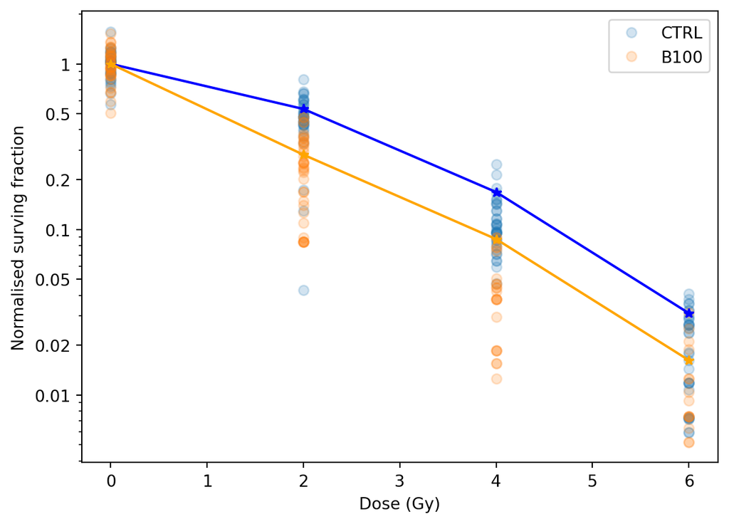

```python
rt_data = pd.read_csv("Data/CFA_data-BMP4-RT Human GSCs.csv")

# filter out doses above 6Gy
rt_data = rt_data[rt_data["dose"] <= 6]

# get GBM1a
GBM1a_rt_data = rt_data[rt_data["cline"] == "GBM1a"]

# keep only replicates that have measurements at 0,2,4,6 Gy
keep_reps = []
for rep in GBM1a_rt_data["rep"].unique():
    test = GBM1a_rt_data[GBM1a_rt_data["rep"] == rep]
    if len(test["dose"].unique()) == 4:
        keep_reps.append(rep)
    print(keep_reps)

GBM1a_rt_data = GBM1a_rt_data[GBM1a_rt_data['rep'].isin(keep_reps)]

# Normalise the data by treatment group and dose and replicate
GBM1a_rt_data["norm_pe"] = 0 # initialisea column with all 0s

groups = GBM1a_rt_data["group"].unique()

for rep in keep_reps:
    for group in groups:
        # Filter the DataFrame for the current replicate and group
        test = GBM1a_rt_data[(GBM1a_rt_data["rep"] == rep) & (GBM1a_rt_data["group"] == group)]

        # Calculate the mean of 'pe' at dose 0 for normalization
        mean_pe_dose_0 = test[test["dose"] == 0]["pe"].mean()

        # Normalize 'pe' and update 'norm_pe' in the original DataFrame
        GBM1a_rt_data.loc[(GBM1a_rt_data["rep"] == rep) & (GBM1a_rt_data["group"] == group), "norm_pe"] = test["pe"] / mean_pe_dose_0

print(GBM1a_rt_data)

print(GBM1a_rt_data[GBM1a_rt_data["group"]=="B100"])

# plot the data
plt.figure()
plt.plot(GBM1a_rt_data[GBM1a_rt_data["group"] == "CTRL"]["dose"],GBM1a_rt_data[GBM1a_rt_data["group"] == "CTRL"]["norm_pe"],'o', alpha = 0.2)
plt.plot(GBM1a_rt_data[GBM1a_rt_data["group"] == "B100"]["dose"],GBM1a_rt_data[GBM1a_rt_data["group"] == "B100"]["norm_pe"],'o',alpha = 0.2)

RT_to_plot = RT_post_size/RT_post_size[0,:]
#plt.plot(RT_doses,RT_post_size/RT_post_size[0,:],'-*')
plt.plot(RT_doses, RT_to_plot[:,0],'b-*')
plt.plot(RT_doses, RT_to_plot[:,1],'-*', color='orange')

plt.legend(["CTRL", "B100"])
plt.xlabel("Dose (Gy)")
plt.ylabel("Normalised surving fraction")
plt.yscale('log')
ticks = [0.01,0.02,0.05,0.1,0.2,0.5,1]
ticks_str = list(map(str, ticks)) # Convert each number to a string
plt.yticks(ticks, ticks_str)
plt.savefig("png/simulated_dose_response_GBM1a.png")
plt.savefig("svg/simulated_dose_response_GBM1a.svg")
plt.show()
```

## 4.2 QNS120

doubling time is 43.5243hrs (1.8135125days) according to this the growth should be

$$N(t) = N_0 2^{t/T}$$

```python
N = s0*2**(48/43.5243)
print("Expected size of colon after 48hrs for GMB1a")
print(N)
```

```
Expected size of colon after 48hrs for GMB1a
0.21477591389744
```

```python
### import params
from gsc_model_params import *

### override some parameters ###
Ps_max = 1 # Max probability of self renewal
Ps_min = 0

s0 = 0.1 # Initial GSCs
dt = 0.01 # time step
t_rad = 2 # time of radiotherapy
t_assay = dt # time of assay after radiotherapy
t_final = t_rad + t_assay

RT_doses = [0,2,4,6] # diffent doses of radiation used in assay
psi_values = [0,0.155] # different values of psi used in assay
psi_colors = list(mcolors.TABLEAU_COLORS)

BMP4_dose = 10 # bmp4 dose is now fixed

nRT = len(RT_doses) # number of RT doses
npsi = len(psi_values) # number of BMP4 doses

# to store time and tumor size at RT and survival assay
RT_pre_size = np.zeros((nRT,npsi))
RT_pre_t = np.zeros((nRT,npsi))
RT_post_size = np.zeros((nRT,npsi))
RT_post_t = np.zeros((nRT,npsi))
assay_size = np.zeros((nRT,npsi))
assay_t = np.zeros((nRT,npsi))

# use the mean of the fitted distribution as an example realistic proliferation rate
pro_rate = 81.5


# Define proliferation rates for the diffent cell pops
mv = mv_rho_scale*pro_rate*np.ones(n)
ms = ms_mv_scale*mv[0]
mv[n-1] = 0

# calc alpha as proportional to rho
#alpha = gmf.calc_alpha_from_rho(pro_rate, alpha_rho_scale)
#beta = gmf.calc_beta(alpha, ratio=3)

# According to the RT data fits for GBM1a we get
alpha = 0
beta = 0.029743166*(100/13)


# set up time grid
t = np.arange(0, t_final+dt/2, dt)
nt = len(t)


# set up array to store model solution
u_all = []
VS_all = []
N_all = []


for ipsi in range(npsi) :
    for j in range(nRT):

        # set up array to store model solution
        u = np.zeros((nt,n+1))
        VS = np.zeros(nt)
        N = np.zeros(nt)

        # define IC
        u[0,0] = s0
        VS[0] = np.sum(u[0,1:n+1]) # sum the 1th to nth entries
        N[0] = u[0,0] + VS[0]

        i = 0
        while t[i] < t_final:
                if t[i] <= t_rad :
                    Ps = Ps_min + (Ps_max - Ps_min)*(1 / (1 + psi_values[ipsi]*BMP4_dose))
                else :
                    Ps = Ps_max

                u[i+1,:] = u[i,:] + dt * gmf.gsc_model_dudt(u[i,:],n,Ps,k,ms,mv,delta_s,delta_v)
                # apply radiation
                if t[i] == t_rad :
                    u[i+1,:] = gmf.radiation(u[i+1,:],alpha,beta,eta,mu,d=RT_doses[j])
                    RT_pre_size[j,ipsi] = np.sum(u[i,:])
                    RT_pre_t[j,ipsi] = t[i]
                    RT_post_size[j,ipsi] = np.sum(u[i+1,:])
                    RT_post_t[j,ipsi] = t[i+1]

                VS[i+1] = np.sum(u[i+1,1:n+1])
                N[i+1] = u[i+1,0] + VS[i+1]

                i = i + 1

        u_all.append(u)
        VS_all.append(VS)
        N_all.append(N)
        print("Actuall size after 48hrs")
        print(N[-2]) # need to print second last item as the last one has had RT applied

print("Stem cell fraction just before RT")
print(1- VS[-2]/N[-2])

print("According to DLQ stem cell fraction should be")
print(0.4063945)
```

```
Actuall size after 48hrs
0.21285271531860234
Actuall size after 48hrs
0.21285271531860234
Actuall size after 48hrs
0.21285271531860234
Actuall size after 48hrs
0.21285271531860234
Actuall size after 48hrs
0.21159158597020183
Actuall size after 48hrs
0.21159158597020183
Actuall size after 48hrs
0.21159158597020183
Actuall size after 48hrs
0.21159158597020183
Stem cell fraction just before RT
0.4003939850385404
According to DLQ stem cell fraction should be
0.4063945
```

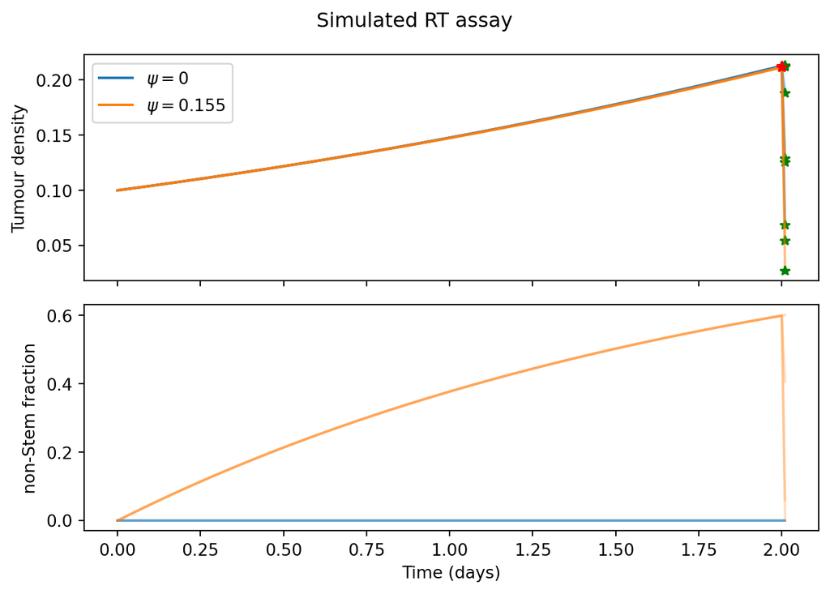

```python
fig, axs = plt.subplots(2, sharex=True)
w = 0
BMP4_colors = list(mcolors.TABLEAU_COLORS)
for ipsi in range(npsi) :
    for j in range(nRT):

        axs[1].plot(t,VS_all[w]/N_all[w], psi_colors[ipsi], alpha=0.25)
        axs[0].plot(t,N_all[w],psi_colors[ipsi], alpha = 0.5)

        axs[0].plot(RT_pre_t[j,ipsi],RT_pre_size[j,ipsi],'r*',label='_nolegend_')
        axs[0].plot(RT_post_t[j,ipsi],RT_post_size[j,ipsi],'g*',label='_nolegend_')

        w = w + 1

axs[1].set(xlabel="Time (days)")
axs[1].set(ylabel="non-Stem fraction")
axs[0].set(ylabel="Tumour density")
axs[1].set(ylabel="non-Stem fraction")
fig.suptitle("Simulated RT assay")
leg = axs[0].legend([r"$\psi = 0$",fr"$\psi = {psi_values[1]}$"], loc='upper left')
leg.legend_handles[0].set_color('tab:blue')
leg.legend_handles[1].set_color('tab:orange')
#leg.legend_handles[2].set_color('tab:green')
#leg.legend_handles[3].set_color('tab:red')
#leg.legend_handles[4].set_color('tab:purple')
leg.legend_handles[0].set_alpha(1)
leg.legend_handles[1].set_alpha(1)
#leg.legend_handles[2].set_alpha(1)
#leg.legend_handles[3].set_alpha(1)
#leg.legend_handles[4].set_alpha(1)
plt.tight_layout()
#plt.savefig("../SMB_figs/simulated_RT_assay.svg")
```

Plot simulated dose respones

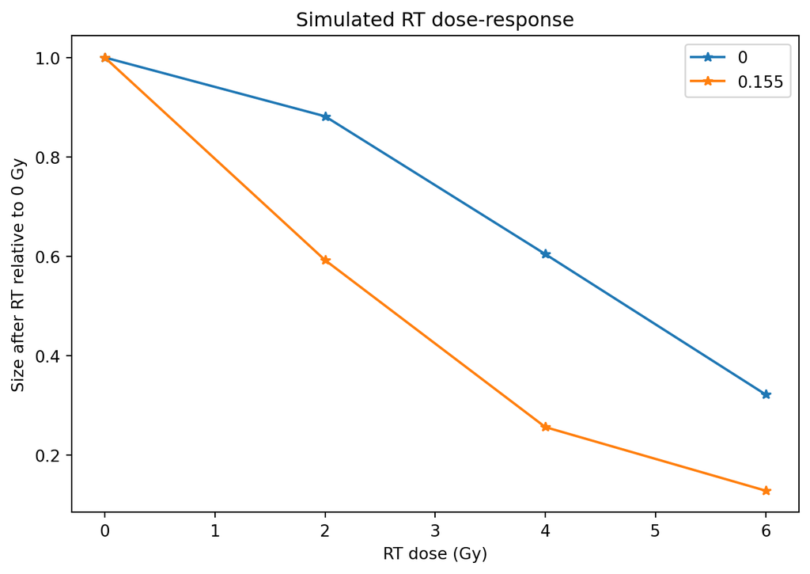

```python
fig_DR2, ax_DR2 = plt.subplots()
ax_DR2.plot(RT_doses,RT_post_size/RT_post_size[0,:],'-*')
ax_DR2.set(xlabel="RT dose (Gy)")
ax_DR2.set(ylabel="Size after RT relative to 0 Gy")
ax_DR2.set_title("Simulated RT dose-response")
ax_DR2.legend(psi_values)
plt.tight_layout()
#plt.savefig("../SMB_figs/simulated_dose_response.svg")
```

Load in the real survival data to fit to.

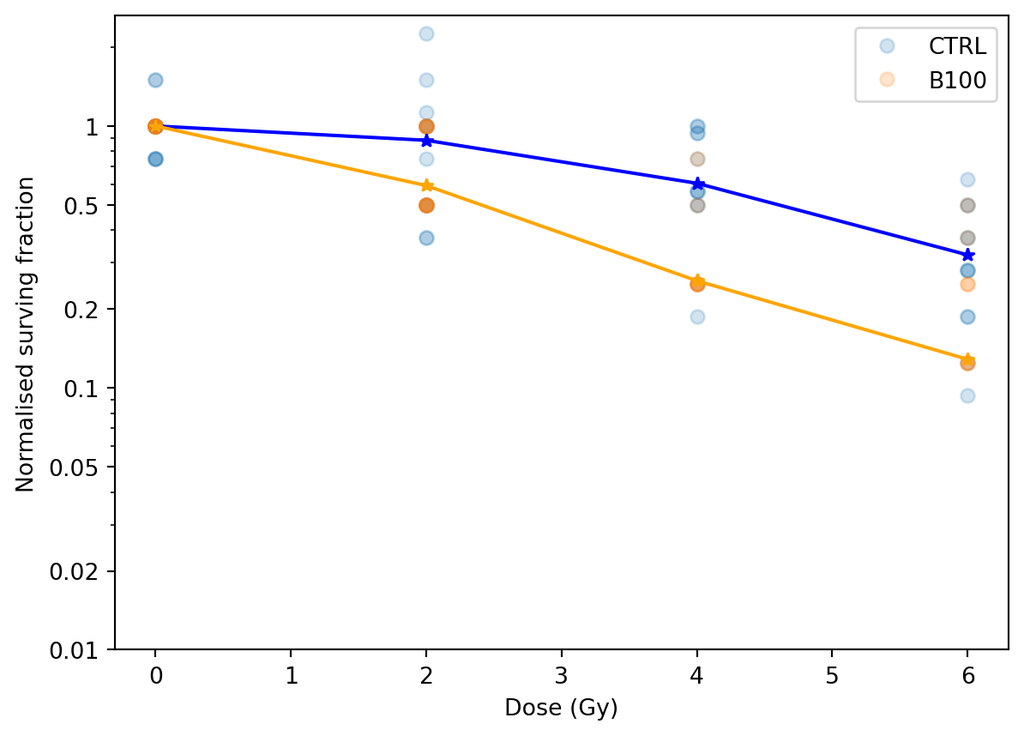

```python
rt_data = pd.read_csv("Data/CFA_data-BMP4-RT Human GSCs.csv")

# filter out doses above 6Gy
rt_data = rt_data[rt_data["dose"] <= 6]

# get QNS120
QNS120_rt_data = rt_data[rt_data["cline"] == "QNS120"]

# keep only replicates that have measurements at 0,2,4,6 Gy
keep_reps = []
for rep in QNS120_rt_data["rep"].unique():
    test = QNS120_rt_data[QNS120_rt_data["rep"] == rep]
    if len(test["dose"].unique()) == 4:
        keep_reps.append(rep)
    #print(keep_rep)

QNS120_rt_data = QNS120_rt_data[QNS120_rt_data['rep'].isin(keep_reps)]

# Normalise the data by treatment group and dose and replicate
QNS120_rt_data["norm_pe"] = 0 # initialisea column with all 0s

groups = QNS120_rt_data["group"].unique()

for rep in keep_reps:
    for group in groups:
        # Filter the DataFrame for the current replicate and group
        test = QNS120_rt_data[(QNS120_rt_data["rep"] == rep) & (QNS120_rt_data["group"] == group)]

        # Calculate the mean of 'pe' at dose 0 for normalization
        mean_pe_dose_0 = test[test["dose"] == 0]["pe"].mean()

        # Normalize 'pe' and update 'norm_pe' in the original DataFrame
        QNS120_rt_data.loc[(QNS120_rt_data["rep"] == rep) & (QNS120_rt_data["group"] == group), "norm_pe"] = test["pe"] / mean_pe_dose_0


# plot the data
plt.figure()
plt.plot(QNS120_rt_data[QNS120_rt_data["group"] == "CTRL"]["dose"],QNS120_rt_data[QNS120_rt_data["group"] == "CTRL"]["norm_pe"],'o', alpha = 0.2)
plt.plot(QNS120_rt_data[QNS120_rt_data["group"] == "B100"]["dose"],QNS120_rt_data[QNS120_rt_data["group"] == "B100"]["norm_pe"],'o',alpha = 0.2)

RT_to_plot = RT_post_size/RT_post_size[0,:]
#plt.plot(RT_doses,RT_post_size/RT_post_size[0,:],'-*')
plt.plot(RT_doses, RT_to_plot[:,0],'b-*')
plt.plot(RT_doses, RT_to_plot[:,1],'-*', color='orange')

plt.legend(["CTRL", "B100"])
plt.xlabel("Dose (Gy)")
plt.ylabel("Normalised surving fraction")
plt.yscale('log')
ticks = [0.01,0.02,0.05,0.1,0.2,0.5,1]
ticks_str = list(map(str, ticks)) # Convert each number to a string
plt.yticks(ticks, ticks_str)
plt.show()
```